# Project: Investigate a Dataset (Replace this with something more specific!)

#### Now its all fine !

```python
df_income_float.info()
```

```
<class 'pandas.core.frame.DataFrame'>
RangeIndex: 195 entries, 0 to 194
Data columns (total 15 columns):
country    195 non-null object
2005       195 non-null float64
2006       195 non-null float64
2007       195 non-null float64
2008       195 non-null float64
2009       195 non-null float64
2010       195 non-null float64
2011       195 non-null float64
2012       195 non-null float64
2013       195 non-null float64
2014       195 non-null float64
2015       195 non-null float64
2016       195 non-null float64
2017       195 non-null float64
2018       195 non-null float64
dtypes: float64(14), object(1)
memory usage: 23.0+ KB
```

```python
df_whr.info()
```

```
<class 'pandas.core.frame.DataFrame'>
RangeIndex: 163 entries, 0 to 162
Data columns (total 15 columns):
country    163 non-null object
2005       163 non-null float64
2006       163 non-null float64
2007       163 non-null float64
2008       163 non-null float64
2009       163 non-null float64
2010       163 non-null float64
2011       163 non-null float64
2012       163 non-null float64
2013       163 non-null float64
2014       163 non-null float64
2015       163 non-null float64
2016       163 non-null float64
2017       163 non-null float64
2018       163 non-null float64
dtypes: float64(14), object(1)
memory usage: 19.2+ KB
```

#### checking that every data without k still the same and checking that every data with k is transformed...

```python
# making sure that the iteration does not affect the values without "k"
float(df_income['2006'][0]) == df_income_float['2006'][0]
```

```
True
```

```python
df_income['2006'][4]
```

```
'87.1k'
```

```python
df_income_float['2006'][4]
```

```
87100.0
```

```python
df_income = df_income_float.copy()
```

#### here we gonna make versions of datasets

> : we will make sure that the three datasets (income,whr,hdi) is the same because we will need them later

> : we will make is to allign all 3 variables (hdi,whr,income) with each other without handling the information of (country,year)

#### in under cell we will rename every year columns in each dataframe to the data frame which will help us to the next part

```python
# renaming every dataframe to merge it
df_whr.rename(columns=lambda x: x[:10] + '_whr',inplace=True)
df_hdi.rename(columns=lambda x: x[:10] + '_hdi',inplace=True)
df_income.rename(columns=lambda x: x[:10] + '_income',inplace=True)
## renaming the country to merge it, with union cell
df_whr.rename(columns={'country_whr':'country'},inplace=True)
df_hdi.rename(columns={'country_hdi':'country'},inplace=True)
df_income.rename(columns={'country_income':'country'},inplace=True)
```

#### merging... this is the first version

```python
# inner join to all the dataframes
df= df_whr.merge(df_hdi,on='country')
df= df.merge(df_income,on='country')
```

```python
df
```

|  | country | 2005_whr | 2006_whr | 2007_whr | 2008_whr | 2009_whr | 2010_whr | 2011_whr | 2012_whr | 2013_whr | ... | 2009_income | 2010_income | 2011_income | 2012_income | 2013_income | 2014_income | 2015_income | 2016_income | 2017_income | 2018_income |
| --- | --- | --- | --- | --- | --- | --- | --- | --- | --- | --- | --- | --- | --- | --- | --- | --- | --- | --- | --- | --- | --- |
| 0 | Afghanistan | 36.091667 | 36.091667 | 36.091667 | 37.200000 | 44.0 | 47.600000 | 38.3 | 37.8 | 35.7 | ... | 1500.0 | 1670.0 | 1630.0 | 1770.0 | 1810.0 | 1800.0 | 1770.0 | 1760.0 | 1760.0 | 1740.0 |
| 1 | Albania | 49.808333 | 49.808333 | 46.300000 | 49.808333 | 54.9 | 52.700000 | 58.7 | 55.1 | 45.5 | ... | 9530.0 | 9930.0 | 10200.0 | 10400.0 | 10500.0 | 10700.0 | 11000.0 | 11400.0 | 11800.0 | 12300.0 |
| 2 | United Arab Emirates | 68.358333 | 67.300000 | 68.358333 | 68.358333 | 68.7 | 71.000000 | 71.2 | 72.2 | 66.2 | ... | 58800.0 | 55400.0 | 56600.0 | 57900.0 | 60400.0 | 62900.0 | 65800.0 | 67000.0 | 66700.0 | 66600.0 |
| 3 | Argentina | 63.307143 | 63.100000 | 60.700000 | 59.600000 | 64.2 | 64.400000 | 67.8 | 64.7 | 65.8 | ... | 17300.0 | 18900.0 | 19800.0 | 19400.0 | 19600.0 | 18900.0 | 19200.0 | 18600.0 | 18900.0 | 18300.0 |
| 4 | Armenia | 44.564286 | 42.900000 | 48.800000 | 46.500000 | 41.8 | 43.700000 | 42.6 | 43.2 | 42.8 | ... | 6530.0 | 6700.0 | 7020.0 | 7510.0 | 7720.0 | 7950.0 | 8170.0 | 8160.0 | 8750.0 | 9180.0 |
| ... | ... | ... | ... | ... | ... | ... | ... | ... | ... | ... | ... | ... | ... | ... | ... | ... | ... | ... | ... | ... | ... |
| 131 | Vietnam | 52.971429 | 52.900000 | 54.200000 | 54.800000 | 53.0 | 53.000000 | 57.7 | 55.3 | 50.2 | ... | 4210.0 | 4430.0 | 4660.0 | 4860.0 | 5070.0 | 5310.0 | 5610.0 | 5900.0 | 6230.0 | 6610.0 |
| 132 | Yemen | 38.575000 | 38.575000 | 44.800000 | 38.575000 | 48.1 | 43.500000 | 37.5 | 40.6 | 42.2 | ... | 4360.0 | 4570.0 | 3880.0 | 3860.0 | 3940.0 | 3830.0 | 3110.0 | 2620.0 | 2400.0 | 2360.0 |
| 133 | South Africa | 48.507143 | 50.800000 | 52.000000 | 53.500000 | 52.2 | 46.500000 | 49.3 | 51.3 | 36.6 | ... | 11800.0 | 12000.0 | 12200.0 | 12300.0 | 12400.0 | 12400.0 | 12400.0 | 12200.0 | 12200.0 | 12100.0 |
| 134 | Zambia | 45.638462 | 48.200000 | 40.000000 | 47.300000 | 52.6 | 45.638462 | 50.0 | 50.1 | 52.4 | ... | 3120.0 | 3340.0 | 3420.0 | 3570.0 | 3630.0 | 3690.0 | 3680.0 | 3700.0 | 3720.0 | 3740.0 |
| 135 | Zimbabwe | 39.785714 | 38.300000 | 32.800000 | 31.700000 | 40.6 | 46.800000 | 48.5 | 49.6 | 46.9 | ... | 1630.0 | 1930.0 | 2170.0 | 2490.0 | 2490.0 | 2510.0 | 2510.0 | 2490.0 | 2570.0 | 2620.0 |

136 rows × 43 columns

#### here we gonna make the second version, without the year and country

```python
# here we allign every 3 data points to each other
df_new = pd.DataFrame(columns=['whr','hdi','income'])
for i in range(2005,2019):
    series = pd.concat([df[str(i)+'_whr'],
                       df[str(i)+'_hdi'],
                       df[str(i)+'_income']],
                       axis=1,
                       keys=df_new.columns)

    data = pd.DataFrame(data=series)
    df_new = df_new.append(data,ignore_index=True)
```

```python
df['2005_hdi'].head(5)
```

```
0    0.410
1    0.702
2    0.809
3    0.777
4    0.694
Name: 2005_hdi, dtype: float64
```

```python
df_new.head(5) ## in these two cell we want to check the alligning... all looks fine and correct
```

|  | whr | hdi | income |
| --- | --- | --- | --- |
| 0 | 36.091667 | 0.410 | 1100.0 |
| 1 | 49.808333 | 0.702 | 7430.0 |
| 2 | 68.358333 | 0.809 | 91600.0 |
| 3 | 63.307143 | 0.777 | 15600.0 |
| 4 | 44.564286 | 0.694 | 5360.0 |

```python
df_new.duplicated().any().sum() # checking for duplicated...
```

```
1
```

```python
df_new.drop_duplicates(inplace=True) #dropping duplicated...
```

```python
df_new.isnull().sum() # checking for nulls
```

```
whr       0
hdi       0
income    0
dtype: int64
```

```python
df_new.dropna(inplace=True) # dropping nulls (no need to fill them we have enough data)
```

```python
df_new.duplicated().any().sum() == 0 and df_new.isnull().sum().any() == False # checking that every thing is good
```

```
True
```

```python
df = df_new.copy()
```

### taking a look at two datasets

```python
df.head(5)
```

|  | whr | hdi | income |
| --- | --- | --- | --- |
| 0 | 36.091667 | 0.410 | 1100.0 |
| 1 | 49.808333 | 0.702 | 7430.0 |
| 2 | 68.358333 | 0.809 | 91600.0 |
| 3 | 63.307143 | 0.777 | 15600.0 |
| 4 | 44.564286 | 0.694 | 5360.0 |

```python
df_income.head(5)
```

|  | country | 2005_income | 2006_income | 2007_income | 2008_income | 2009_income | 2010_income | 2011_income | 2012_income | 2013_income | 2014_income | 2015_income | 2016_income | 2017_income | 2018_income |
| --- | --- | --- | --- | --- | --- | --- | --- | --- | --- | --- | --- | --- | --- | --- | --- |
| 0 | Afghanistan | 1100.0 | 1120.0 | 1250.0 | 1270.0 | 1500.0 | 1670.0 | 1630.0 | 1770.0 | 1810.0 | 1800.0 | 1770.0 | 1760.0 | 1760.0 | 1740.0 |
| 1 | Angola | 5110.0 | 5500.0 | 6040.0 | 6470.0 | 6290.0 | 6360.0 | 6350.0 | 6650.0 | 6730.0 | 6810.0 | 6650.0 | 6260.0 | 6050.0 | 5730.0 |
| 2 | Albania | 7430.0 | 7910.0 | 8450.0 | 9160.0 | 9530.0 | 9930.0 | 10200.0 | 10400.0 | 10500.0 | 10700.0 | 11000.0 | 11400.0 | 11800.0 | 12300.0 |
| 3 | Andorra | 39800.0 | 42700.0 | 43400.0 | 41400.0 | 41700.0 | 39000.0 | 42000.0 | 41900.0 | 43700.0 | 44900.0 | 46600.0 | 48200.0 | 49800.0 | 51500.0 |
| 4 | United Arab Emirates | 91600.0 | 87100.0 | 77200.0 | 69400.0 | 58800.0 | 55400.0 | 56600.0 | 57900.0 | 60400.0 | 62900.0 | 65800.0 | 67000.0 | 66700.0 | 66600.0 |

```python
df_hdi.head(5)
```

|  | country | 2005_hdi | 2006_hdi | 2007_hdi | 2008_hdi | 2009_hdi | 2010_hdi | 2011_hdi | 2012_hdi | 2013_hdi | 2014_hdi | 2015_hdi | 2016_hdi | 2017_hdi | 2018_hdi |
| --- | --- | --- | --- | --- | --- | --- | --- | --- | --- | --- | --- | --- | --- | --- | --- |
| 0 | Afghanistan | 0.410 | 0.419 | 0.431 | 0.436 | 0.447 | 0.464 | 0.465 | 0.479 | 0.485 | 0.488 | 0.490 | 0.491 | 0.493 | 0.496 |
| 2 | Albania | 0.702 | 0.709 | 0.718 | 0.724 | 0.729 | 0.740 | 0.759 | 0.771 | 0.781 | 0.787 | 0.788 | 0.788 | 0.789 | 0.791 |
| 4 | United Arab Emirates | 0.809 | 0.814 | 0.819 | 0.821 | 0.819 | 0.821 | 0.826 | 0.832 | 0.839 | 0.847 | 0.860 | 0.863 | 0.864 | 0.866 |
| 5 | Argentina | 0.777 | 0.801 | 0.806 | 0.810 | 0.810 | 0.818 | 0.823 | 0.823 | 0.824 | 0.825 | 0.828 | 0.828 | 0.832 | 0.830 |
| 6 | Armenia | 0.694 | 0.708 | 0.724 | 0.727 | 0.724 | 0.729 | 0.733 | 0.737 | 0.743 | 0.746 | 0.748 | 0.751 | 0.758 | 0.760 |

```python
df_whr.head(5)
```

|  | country | 2005_whr | 2006_whr | 2007_whr | 2008_whr | 2009_whr | 2010_whr | 2011_whr | 2012_whr | 2013_whr | 2014_whr | 2015_whr | 2016_whr | 2017_whr | 2018_whr |
| --- | --- | --- | --- | --- | --- | --- | --- | --- | --- | --- | --- | --- | --- | --- | --- |
| 0 | Afghanistan | 36.091667 | 36.091667 | 36.091667 | 37.200000 | 44.0 | 47.6 | 38.3 | 37.8 | 35.7 | 31.3 | 39.8 | 42.2 | 26.6 | 26.9 |
| 1 | Angola | 44.200000 | 44.200000 | 44.200000 | 44.200000 | 44.2 | 44.2 | 55.9 | 43.6 | 39.4 | 37.9 | 44.2 | 44.2 | 44.2 | 44.2 |
| 2 | Albania | 49.808333 | 49.808333 | 46.300000 | 49.808333 | 54.9 | 52.7 | 58.7 | 55.1 | 45.5 | 48.1 | 46.1 | 45.1 | 46.4 | 50.0 |
| 3 | United Arab Emirates | 68.358333 | 67.300000 | 68.358333 | 68.358333 | 68.7 | 71.0 | 71.2 | 72.2 | 66.2 | 65.4 | 65.7 | 68.3 | 70.4 | 66.0 |
| 4 | Argentina | 63.307143 | 63.100000 | 60.700000 | 59.600000 | 64.2 | 64.4 | 67.8 | 64.7 | 65.8 | 66.7 | 67.0 | 64.3 | 60.4 | 57.9 |

## Exploratory Data Analysis

> **Tip**: Now that you've trimmed and cleaned your data, you're ready to move on to exploration. Compute statistics and create visualizations with the goal of addressing the research questions that you posed in the Introduction section. It is recommended that you be systematic with your approach. Look at one variable at a time, and then follow it up by looking at relationships between variables.

### Research Question 1: Does the WHR increased in the Gulf in the last few years ?

```python
df_whr.set_index("country",
              inplace = True)
```

```python
df_whr_gulf = df_whr.loc[['Bahrain','Iraq','Kuwait','Oman','Qatar','Saudi Arabia','United Arab Emirates']].copy()
```

```python
df_whr_gulf
```

| country | 2005_whr | 2006_whr | 2007_whr | 2008_whr | 2009_whr | 2010_whr | 2011_whr | 2012_whr | 2013_whr | 2014_whr | 2015_whr | 2016_whr | 2017_whr | 2018_whr |
| --- | --- | --- | --- | --- | --- | --- | --- | --- | --- | --- | --- | --- | --- | --- |
| Bahrain | 58.990000 | 58.990000 | 58.990000 | 58.990000 | 57.0 | 59.4 | 48.2 | 50.3 | 66.90 | 61.70 | 60.1 | 61.70 | 62.30 | 58.990000 |
| Iraq | 46.581818 | 46.581818 | 46.581818 | 45.900000 | 47.8 | 50.7 | 47.3 | 46.6 | 47.30 | 45.40 | 44.9 | 44.10 | 44.60 | 46.581818 |
| Kuwait | 62.745455 | 60.800000 | 62.745455 | 62.745455 | 65.9 | 68.0 | 63.8 | 62.2 | 64.80 | 61.80 | 61.5 | 59.50 | 60.90 | 62.745455 |
| Oman | 68.500000 | 68.500000 | 68.500000 | 68.500000 | 68.5 | 68.5 | 68.5 | 68.5 | 68.50 | 68.50 | 68.5 | 68.50 | 68.50 | 68.500000 |
| Qatar | 65.680000 | 65.680000 | 65.680000 | 65.680000 | 64.2 | 68.5 | 65.9 | 66.1 | 65.68 | 65.68 | 63.7 | 65.68 | 65.68 | 65.680000 |
| Saudi Arabia | 70.800000 | 65.271429 | 72.700000 | 68.100000 | 61.5 | 63.1 | 67.0 | 64.0 | 65.00 | 62.80 | 63.5 | 64.70 | 62.90 | 63.600000 |
| United Arab Emirates | 68.358333 | 67.300000 | 68.358333 | 68.358333 | 68.7 | 71.0 | 71.2 | 72.2 | 66.20 | 65.40 | 65.7 | 68.30 | 70.40 | 66.000000 |

#### in this graph we see that there is a fluctuate in whr which conclude to us that the happy score have a in each year in the gulf...

#### and it is not stable

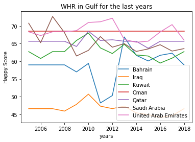

```python
x = [2005,2006,2007,2008,2009,2010,2011,2012,2013,2014,2015,2016,2017,2018]
for index, row in df_whr_gulf.iterrows():
    plt.plot(x,row.values, label = index)
plt.title('WHR in Gulf for the last years')
plt.ylabel('Happy Score')
plt.xlabel('years')
plt.legend()
plt.show()
```

#### in this graph also we see that the mean of whr in the gulf does not have a stable increasing or decreasing

```
<BarContainer object of 14 artists>
```

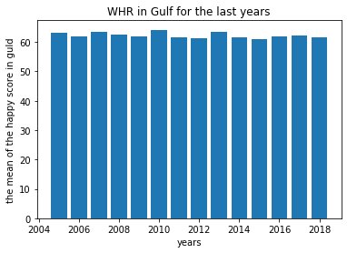

```python
plt.title('WHR in Gulf for the last years')
plt.ylabel('the mean of the happy score in guld')
plt.xlabel('years')
plt.bar(x,df_whr_gulf.mean().values)
```

### Research Question 2: Does the HDI increased in the Gulf in the last few years ?

```python
df_hdi.set_index("country",
              inplace = True)
```

```python
df_hdi_gulf = df_hdi.loc[['Bahrain','Iraq','Kuwait','Oman','Qatar','Saudi Arabia','United Arab Emirates']].copy()
```

> : Oman is not in the dataset, so we will except it

```python
df_hdi_gulf = df_hdi.loc[['Bahrain','Iraq','Kuwait','Qatar','Saudi Arabia','United Arab Emirates']].copy()
```

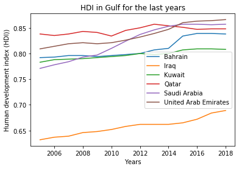

```python
x = [2005,2006,2007,2008,2009,2010,2011,2012,2013,2014,2015,2016,2017,2018]
for index, row in df_hdi_gulf.iterrows():
    plt.plot(x,row.values, label = index)
plt.title('HDI in Gulf for the last years')
plt.xlabel('Years')
plt.ylabel('Human development index (HDI))')
plt.legend()
plt.show()
```

#### in this graph we see that the mean of all gulf contries HDI have increased... which conclude to us that there is increasing in life quality in the gulf region

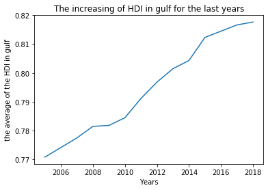

```python
plt.title('The increasing of HDI in gulf for the last years')
plt.xlabel('Years')
plt.ylabel('the average of the HDI in gulf')
plt.plot(x,df_hdi_gulf.mean().values)
```

### Research Question 3: is there a relation between the average income and the human development index or the happy score ?

#### If we look at this graph, we see that the two variable , (Income) (WHR) have a positive correlation, which conclude to us that there is a effect on income to the happiness

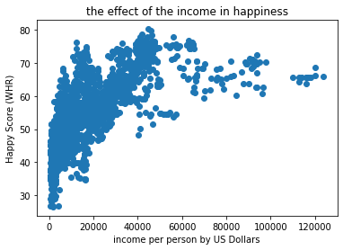

```python
plt.scatter(df.income, df.whr)
plt.title('the effect of the income in happiness')
plt.xlabel('income per person by US Dollars')
plt.ylabel('Happy Score (WHR)')
```

```python
corr_income_whr = df.income.corr(df.whr)
corr_income_whr
```

```
0.6897276331620237
```

#### If we look at this graph, we see that the two variable , (Income) (HDI) have a positive correlation, which conclude to us that there is a effect on income to the life quality of people...

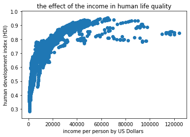

```python
plt.scatter(df.income, df.hdi)
plt.title('the effect of the income in human life quality')
plt.xlabel('income per person by US Dollars ')
plt.ylabel('human development index (HDI)')
plt.show()
```

```python
corr_income_hdi = df.income.corr(df.hdi)
corr_income_hdi
```

```
0.7425127417920309
```

### Research Question 4: is there a relation between (HDI) and (WHR)

#### If we look at this graph, we see that the two variable , (WHR) (HDI) have a high positive correlation, which conclude to us that there is a relation between the life quality and the happiness of the people

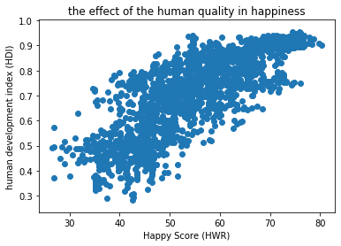

```python
plt.scatter(df.whr, df.hdi)
plt.title('the effect of the human quality in happiness')
plt.xlabel('Happy Score (HWR)')
plt.ylabel('human development index (HDI)')
```

```python
#correlation between the two variables
corr = df.whr.corr(df.hdi)
corr
```

```
0.7995432202436017
```

## Conclusions

> **Result** : our data suggest that:
> 1. There is a big gap between the happy score in each country in the gulf
> 2. There is an increase in Human development index (HDI) in the gulf mostly at every country, which mean a better life quality
> 3. there is mid-high correlation between the income and the hdi and the whr, at any time or country
> 4. there is a high correlation between the happy score and the human development index, which convince to us that the life quality affect the happiness percantage

> **Limitation** :
> 1. there was a missing value in happy score dataframe which we filled up with mean... that may slightly affect the correlation
> 2. there was a country in the gulf Human development index dataframe we did not have informaton in our data which could affect the results